# Explore and Summarize Red Wine by Salma Refaat

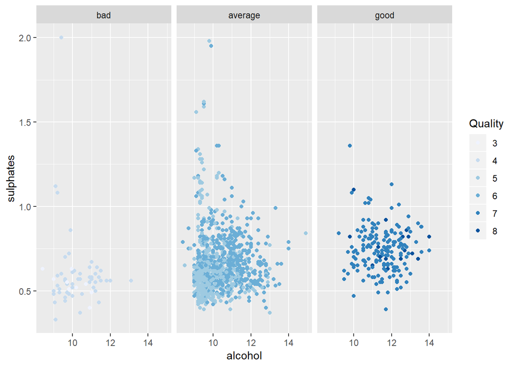

> better wine correspond by better with higher sulphates

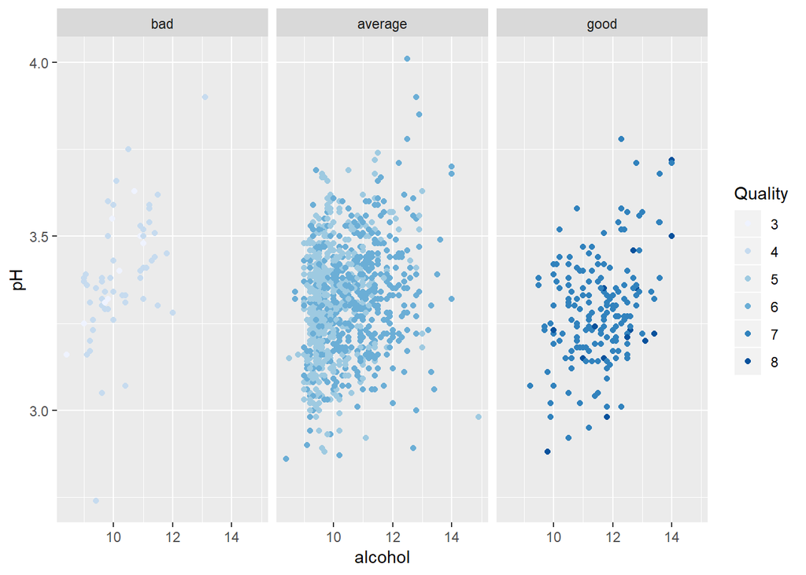

> In specific alcohol pH have ne effect in changing the quality

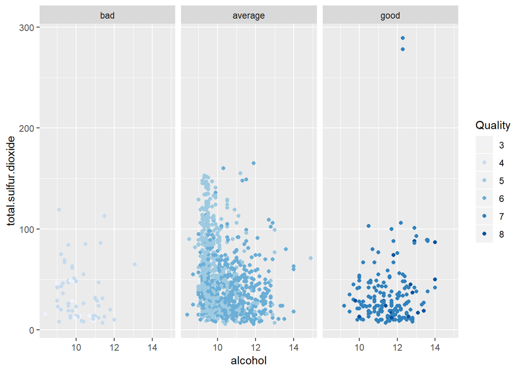

> at specific alcohol total sulfur dioxode have no effect on quality

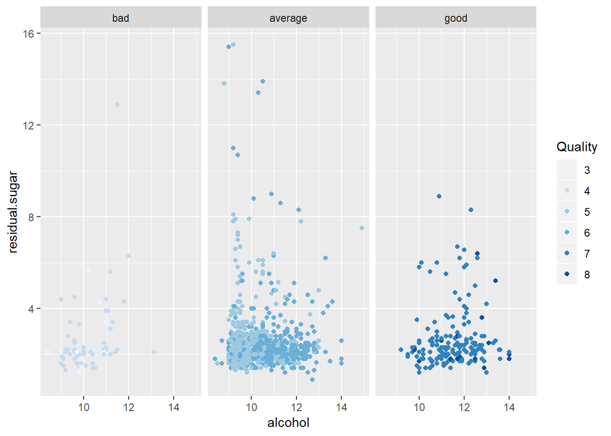

> Again sugar have no affect on quality

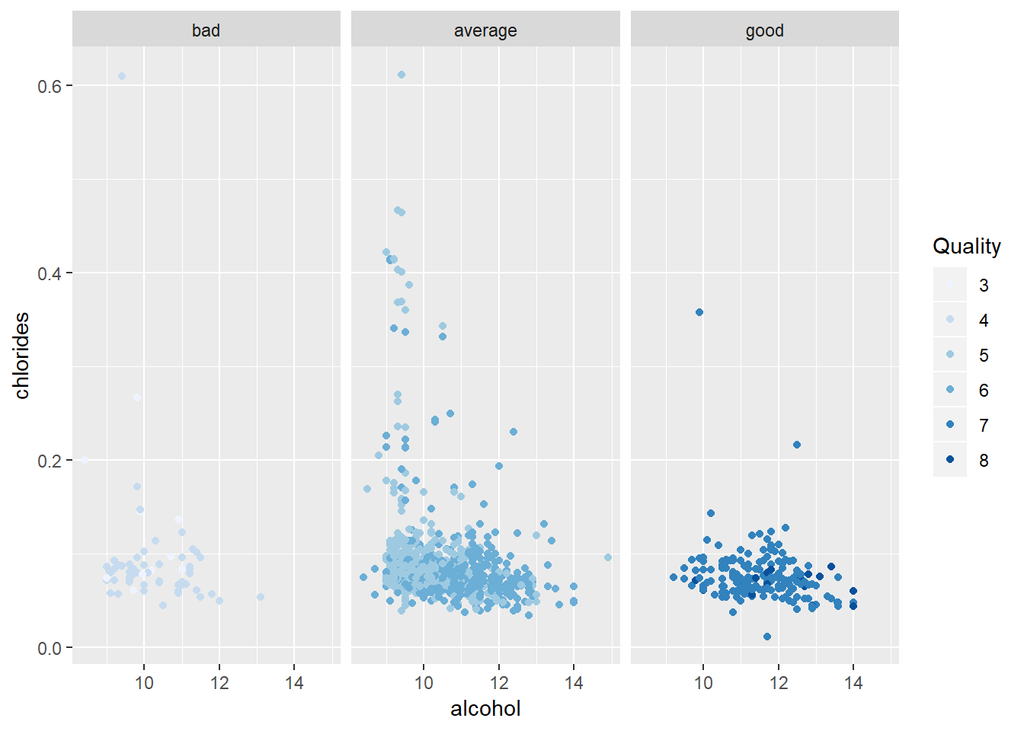

> Chlorides have no affect on quality

### Create Linear Model

> From above we will build our models based on the following predictors variables which prove that they have effects on our response variable(quality) 1- Alcohol 2- Volatile acidity 3- citric acid 4- sulphates

```
##
## Calls:
## m1: lm(formula = as.numeric(quality) ~ alcohol, data = Rwine)
## m2: lm(formula = as.numeric(quality) ~ alcohol + sulphates, data = Rwine)
## m3: lm(formula = as.numeric(quality) ~ alcohol + sulphates + citric.acid,
##     data = Rwine)
## m4: lm(formula = as.numeric(quality) ~ alcohol + sulphates + citric.acid +
##     volatile.acidity, data = Rwine)
##
## ============================================================================
##                          m1            m2            m3            m4
## ----------------------------------------------------------------------------
##   (Intercept)          -0.125        -0.625***     -0.566**       0.646**
##                        (0.175)       (0.177)       (0.176)       (0.201)
##   alcohol               0.361***      0.346***      0.338***      0.309***
##                        (0.017)       (0.016)       (0.016)       (0.016)
##   sulphates                           0.994***      0.814***      0.696***
##                                      (0.102)       (0.107)       (0.103)
##   citric.acid                                       0.513***     -0.079
##                                                    (0.093)       (0.104)
##   volatile.acidity                                               -1.265***
##                                                                  (0.113)
## ----------------------------------------------------------------------------
##   R-squared             0.227         0.270         0.284         0.336
##   adj. R-squared        0.226         0.269         0.282         0.334
##   sigma                 0.710         0.690         0.684         0.659
##   F                   468.267       294.988       210.501       201.777
##   p                     0.000         0.000         0.000         0.000
##   Log-likelihood    -1721.057     -1675.142     -1659.955     -1599.093
##   Deviance            805.870       760.894       746.576       691.852
##   AIC                3448.114      3358.284      3329.910      3210.186
##   BIC                3464.245      3379.793      3356.795      3242.448
##   N                  1599          1599          1599          1599
## ============================================================================
```

> Let’s check for multicollinearity

```
##          alcohol        sulphates      citric.acid volatile.acidity
##         1.044752         1.124597         1.505652         1.498365
```

> ALL the vif is less than 5 The model can be describe as following:

> wine_quality = 0.646+0.309*alcohol+0.696*sulphates-0.079*citric_acid-1.265*volatile_acidity

# Multivariate Analysis

> From above inverstegation we descover the following: 1- Higher alcohol and sulphates produce better wine 2- less volatile acidity produce better wine 3- citric acid have a small amount in determining the quality of the wine

> This model is easy but have Very low R square value, may be linear model is not the best one here , also it’s difficult to predict the edges cases,this can be due to the fact that our dataset comprised mainly of ‘Average’ quality wines and as there were very few data about the ‘Good’ and the ‘Bad’ quality wines in this data set.

# Final Plots and Summary

### Plot One

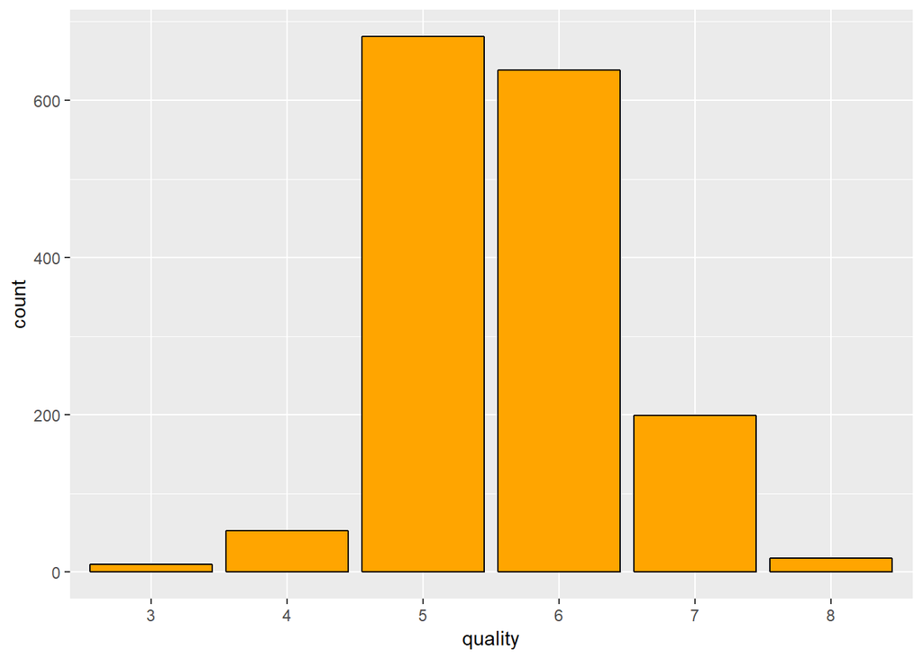

### Description One

The quality range from 3 to 8 ,most of thr data have 5,6 score

### Plot Two

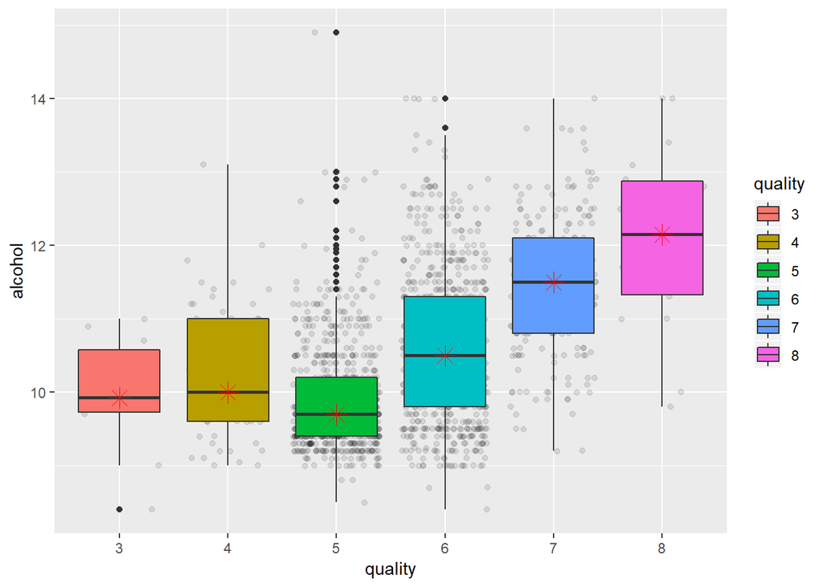

### Plot Three

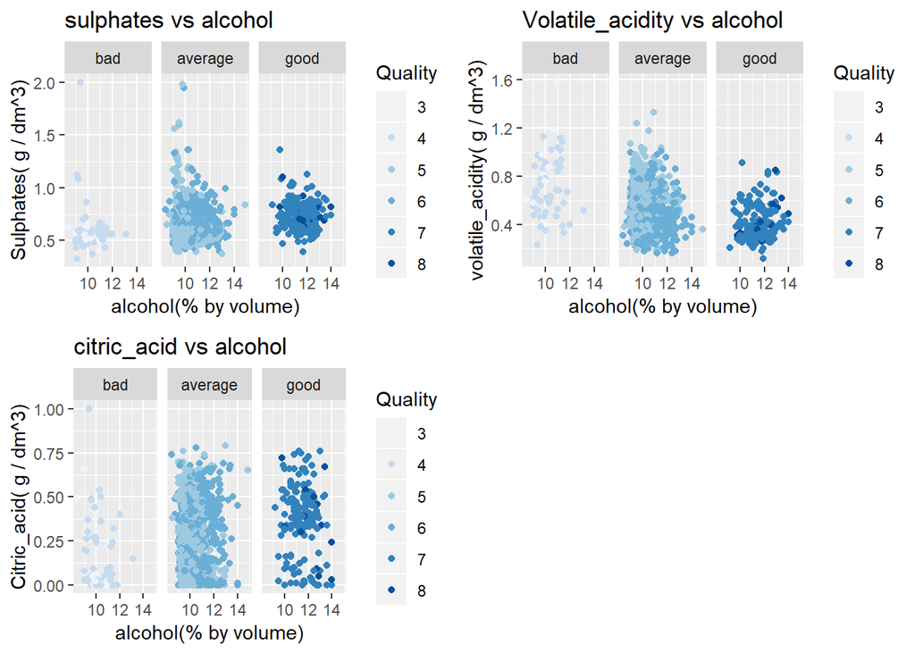

### Description Three

The third plot shows the relationship between quality and the other main components associated with better wine.

# Reflection

> I started my analysis by trying to know each component in our data set and what it is his distribution , I found that our main feature is associated with four main aspects alcohol, sulphates,volatile acidity and citric acid . Along through my exploration i found that volatile acidity is having unexpected pattern with ph this could due to simpson’s paradox . I have built my model based on these relations but my model faced some problems such like low R squared value and the difficulty to predict the edges cases,this can be due to the fact that our dataset comprised mainly of ‘Average’ quality wines and there were very few data about the ‘Good’ and the ‘Bad’ quality wines in this data set.